# MWI: Compare ARC2 and CHIRPS

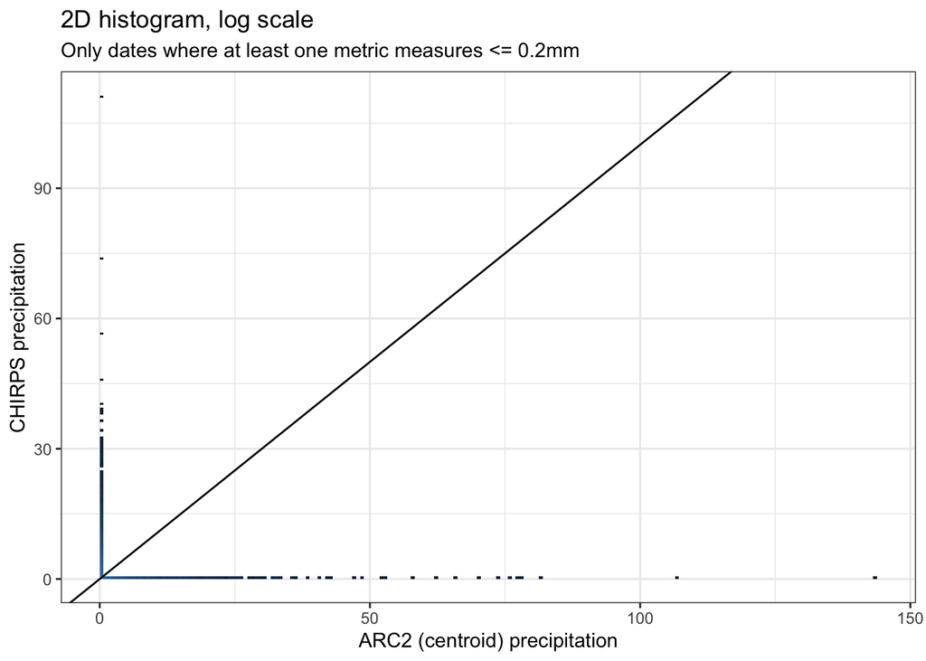

```r
daily_df %>%
  filter(arc2_centroid <= 0.2 | chirps <= 0.2)%>%
  ggplot(aes(x = arc2_centroid,
             y = chirps)) +
  geom_bin2d(bins = 200,
             aes(fill = log(..density..))) +
  theme_bw() +
  geom_abline(intercept = 0) +
  theme(legend.position = "none") +
  labs(title = "2D histogram, log scale",
       subtitle = "Only dates where at least one metric measures <= 0.2mm",
       x = "ARC2 (centroid) precipitation",
       y = "CHIRPS precipitation")
```

The above graph is obviously difficult to interpret given some of the extreme values. We could limit the axes, but might be more intuititive to graph instead the differences.

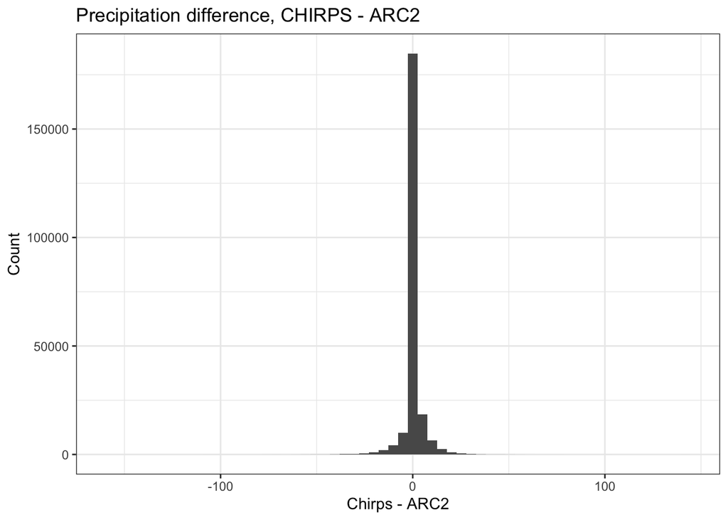

```r
daily_df %>%
  mutate(chirps_arc2_diff = chirps - arc2_centroid) %>%
  ggplot(aes(x = chirps_arc2_diff)) +
  geom_histogram(bins = 60) +
  theme_bw() +
  labs(title = "Precipitation difference, CHIRPS - ARC2",
       x = "Chirps - ARC2",
       y = "Count")
```

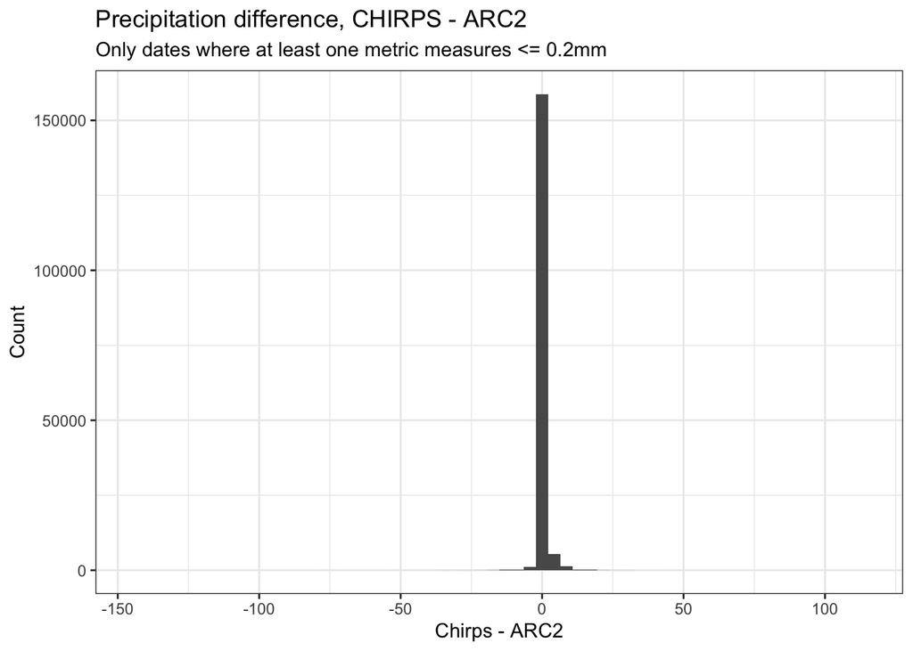

```r
daily_df %>%
  mutate(chirps_arc2_diff = chirps - arc2_centroid) %>%
  filter(arc2_centroid <= 0.2 | chirps <= 0.2) %>%
  ggplot(aes(x = chirps_arc2_diff)) +
  geom_histogram(bins = 60) +
  theme_bw() +
  labs(title = "Precipitation difference, CHIRPS - ARC2",
       subtitle = "Only dates where at least one metric measures <= 0.2mm",
       x = "Chirps - ARC2",
       y = "Count")
```

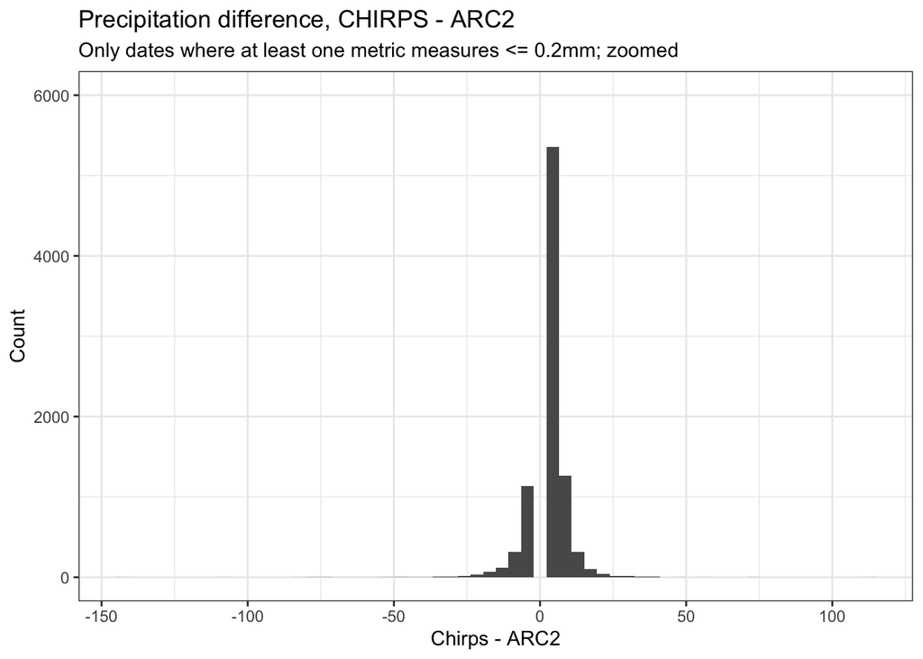

```r
daily_df %>%
  mutate(chirps_arc2_diff = chirps - arc2_centroid) %>%
  filter(arc2_centroid <= 0.2 | chirps <= 0.2) %>%
  ggplot(aes(x = chirps_arc2_diff)) +
  geom_histogram(bins = 60) +
  theme_bw() +
  scale_y_continuous(limits = c(0, 6000)) +
  labs(title = "Precipitation difference, CHIRPS - ARC2",
       subtitle = "Only dates where at least one metric measures <= 0.2mm; zoomed",
       x = "Chirps - ARC2",
       y = "Count")
```

### January / February comparisons

Since our action trigger will be monitored only in January and February 2022, important to validate the comparability of ARC2 and CHIRPS across that period solely to ensure the broader trends still hold true (which indicate that ARC2 is as sufficient if not preferable for dry spell detection).

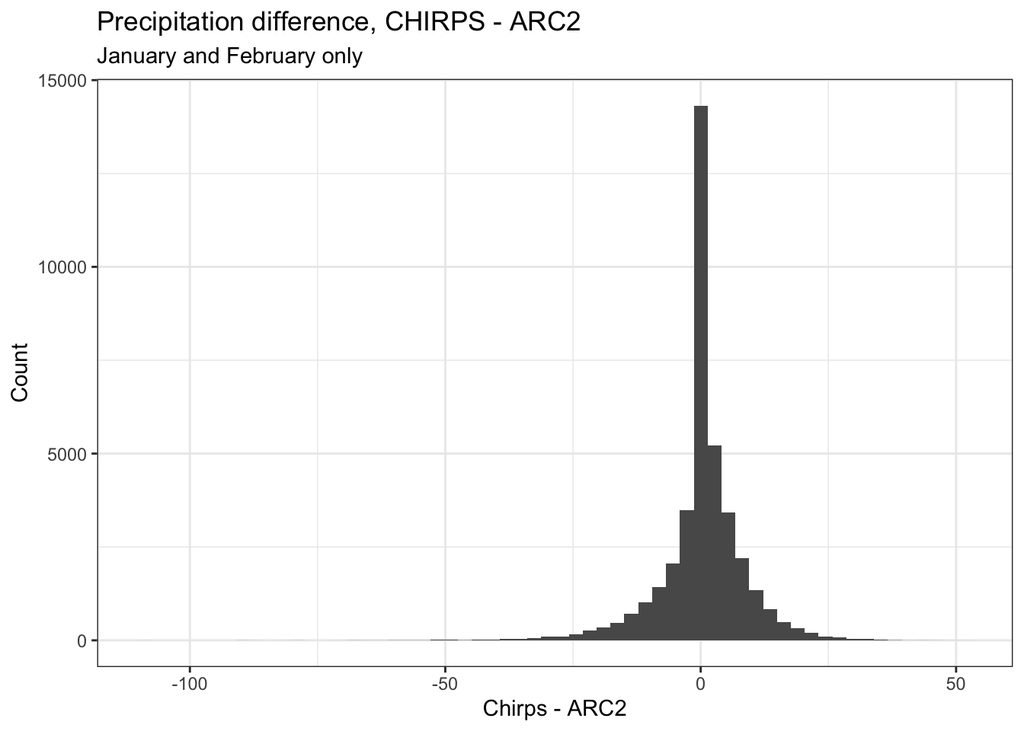

```r
daily_df %>%
  mutate(chirps_arc2_diff = chirps - arc2_centroid) %>%
  filter(lubridate::month(date) <= 2) %>%
  ggplot(aes(x = chirps_arc2_diff)) +
  geom_histogram(bins = 60) +
  theme_bw() +
  labs(title = "Precipitation difference, CHIRPS - ARC2",
       subtitle = "January and February only",
       x = "Chirps - ARC2",
       y = "Count")
```

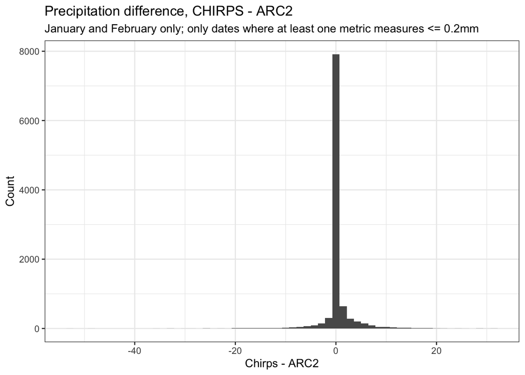

```r
daily_df %>%
  mutate(chirps_arc2_diff = chirps - arc2_centroid) %>%
  filter(arc2_centroid <= 0.2 | chirps <= 0.2,
         lubridate::month(date) <= 2) %>%
  ggplot(aes(x = chirps_arc2_diff)) +
  geom_histogram(bins = 60) +
  theme_bw() +
  labs(title = "Precipitation difference, CHIRPS - ARC2",
       subtitle = "January and February only; only dates where at least one metric measures <= 0.2mm",
       x = "Chirps - ARC2",
       y = "Count")
```

We can again see that CHIRPS data in this period does indeed follow the same trend.

### During mismatched dry spells

Another final piece of checking to do would be to see what is going on with daily values in the periods where one method detects a dry spell but the other detects no overlapping dry spell at all.

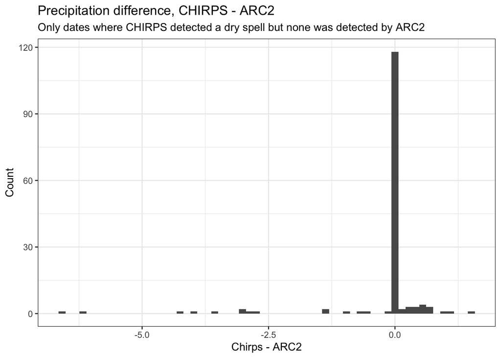

```r
arc2_no_spell_daily <- arc2_chirps_df %>%
  filter(chirps_ds, !arc2_centroid_ds) %>%
  mutate(ds_uid = paste(pcode, lubridate::year(chirps_confirmation), sep = ", ")) %>%
  fuzzy_inner_join(
    daily_df,
    match_fun = list(`==`, `<=`, `>=`),
    by = c(
      "pcode" = "pcode",
      "chirps_start" = "date",
      "chirps_end" = "date"
    )) %>%
  select(pcode = pcode.x,
         ds_uid,
         date,
         chirps,
         arc2_centroid)

arc2_no_spell_daily %>%
  mutate(chirps_arc2_diff = chirps - arc2_centroid) %>%
  ggplot(aes(x = chirps_arc2_diff)) +
  geom_histogram(bins = 60) +
  theme_bw() +
  labs(title = "Precipitation difference, CHIRPS - ARC2",
       subtitle = "Only dates where CHIRPS detected a dry spell but none was detected by ARC2",
       x = "Chirps - ARC2",
       y = "Count")
```

Clearly, by defining our subset, we see many instances where the CHIRPS measured precipitation is lower than ARC2. But where is actually coming about?

```r
arc2_no_spell_daily %>%
  mutate(chirps_arc2_diff = chirps - arc2_centroid,
         chirps_type = ifelse(chirps > 0, "> 0mm", "0mm"),
         ) %>%
  group_by(chirps_type) %>%
  summarize(`ARC2 0mm` = sum(arc2_centroid == 0, na.rm = T),
            `ARC2 > 0mm` = sum(arc2_centroid > 0, na.rm = T),
            `ARC2 > 0mm & > chirps` = sum(arc2_centroid > 0 & arc2_centroid > chirps, na.rm = T))
```

```
## # A tibble: 2 × 4
##   chirps_type `ARC2 0mm` `ARC2 > 0mm` `ARC2 > 0mm & > chirps`
##   <chr>            <int>        <int>                   <int>
## 1 > 0mm               15            9                       5
## 2 0mm                115           12                      12
```

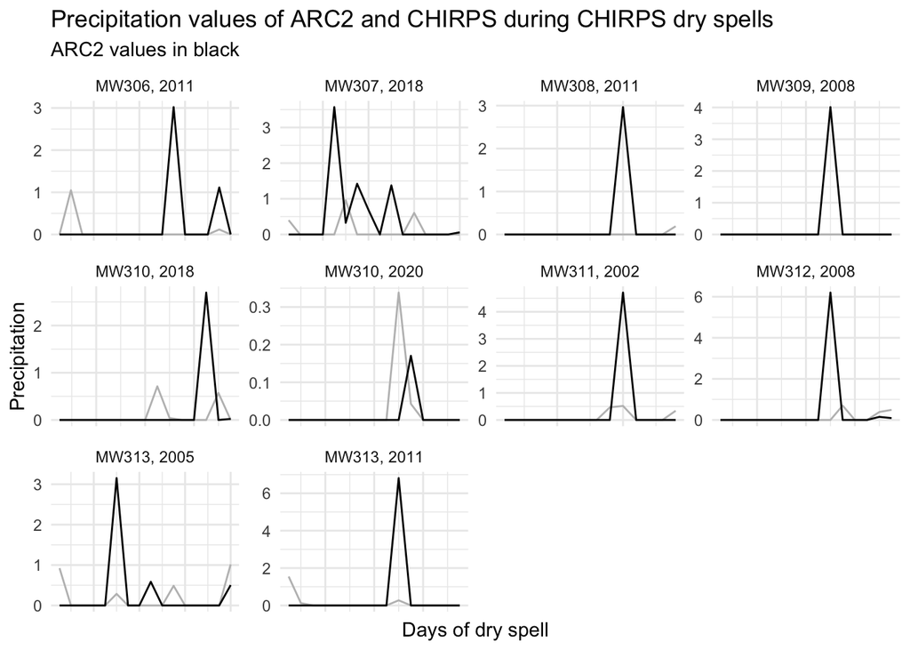

```r
arc2_no_spell_daily %>%
  filter(!is.na(arc2_centroid)) %>%
  group_by(ds_uid) %>%
  arrange(date, .by_group = TRUE) %>%
  mutate(id = row_number()) %>%
  ggplot(aes(x = id)) +
  geom_line(aes(y = chirps), color = "grey") +
  geom_line(aes(y = arc2_centroid)) +
  facet_wrap(~ds_uid, scales = "free") +
  theme_minimal() +
  theme(axis.text.x = element_blank()) +
  labs(x = "Days of dry spell",
       y = "Precipitation",
       title = "Precipitation values of ARC2 and CHIRPS during CHIRPS dry spells",
       subtitle = "ARC2 values in black")
```